# Restructuración Industrial y Sostenibilidad en el Sector Papelero Argentino: El Caso Ledesma

Análisis estratégico de la producción de papel a partir de bagazo de caña de azúcar y su transición hacia envases biodegradables en el complejo agroindustrial Ledesma.

Franca Bielsa (Universidad Nacional de Cuyo) , Rocío Alarcón (Universidad Nacional de Cuyo) , Ignacio Coronado (Universidad Nacional de Cuyo) , Maite Aguilar (Universidad Nacional de Cuyo) , Camila Sotelo (Universidad Nacional de Cuyo)  
2025-06-01

## Introducción

La industria de la celulosa y el papel en Argentina, representada por el complejo agroindustrial Ledesma, cuenta con más de 115 años de trayectoria (Avellaneda, 2023). Su modelo se basa en la integración vertical, utilizando el bagazo de la caña de azúcar como materia prima renovable, lo que posiciona sus productos como alternativas sostenibles frente a la celulosa de madera tradicional (Lacabana, 2019).

A diferencia de los modelos industriales convencionales, Ledesma aprovecha el bagazo —subproducto del proceso azucarero— para producir celulosa y papel, reduciendo significativamente la presión sobre los bosques nativos y disminuyendo la huella de carbono del proceso productivo. Esta integración vertical constituye una ventaja competitiva estructural que ha permitido a la empresa sostener su posición en el mercado durante más de un siglo (Avellaneda, 2023).

## Transformación Digital y Diversificación Productiva

En respuesta a la caída de la demanda de papel para impresión —consecuencia directa de la digitalización— la empresa ha iniciado procesos de transformación digital y robotización, además de diversificar su cartera hacia productos de papel NAT: 100% fibra de caña y 0% químicos blanqueadores (Salatin, 2024).

La línea Ledesma NAT Tissue representa uno de los ejes centrales de esta estrategia de diversificación relacionada. Al combinar las capacidades instaladas en la unidad papelera con una propuesta de valor centrada en la sostenibilidad, la empresa busca capturar segmentos de consumidores con mayor conciencia ambiental, tanto en el mercado doméstico como en mercados de exportación (Salatin, 2024).

## Análisis Estratégico: Hacia el Packaging Compostable

Los diagnósticos actuales sugieren una transición hacia el packaging compostable y productos de papel tissue para mitigar el impacto ambiental del plástico de un solo uso y capturar mercados internacionales que valoran la economía circular (Bellomo, 2025; Guimera Gauna, 2022).

La viabilidad de exportar resmas de hoja A4 de biopapel a mercados como Perú evidencia que la propuesta de valor de Ledesma —trazabilidad agroindustrial, huella de carbono reducida y certificación de origen— constituye una ventaja competitiva sostenible (Guimera Gauna, 2022). Este caso permite identificar los requisitos arancelarios, logísticos y de certificación que condicionan el acceso a mercados con regulaciones ambientales más exigentes.

## Datos de Producción

### Tabla 1. Producción por línea de producto (2020–2022)

Table 1: Table 2: Toneladas producidas por Ledesma según línea de producto (2020–2022)

| Producto | 2020 | 2021 | 2022 |
| --- | --- | --- | --- |
| Papel embalaje | 89.815 | 82.248 | 101.617 |
| Cuadernos y repuestos | 12.235 | 7.380 | 9.985 |
| Papel impresión | 54.011 | 58.448 | 87.043 |
| Artículos librería | 9.931 | 7.736 | 10.788 |

Fuente: Elaboración propia basada en Guimera Gauna (2022).

### Figura 1. Evolución de la producción por línea de producto

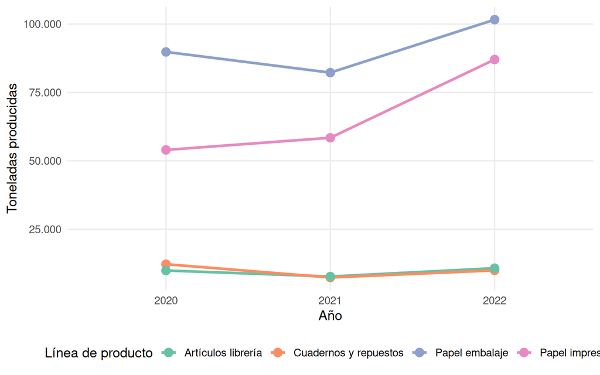

Figure 1: Evolución de la producción en toneladas por línea de producto (2020–2022). Fuente: Elaboración propia basada en Guimera Gauna (2022).

### Figura 2. Composición anual de la producción total

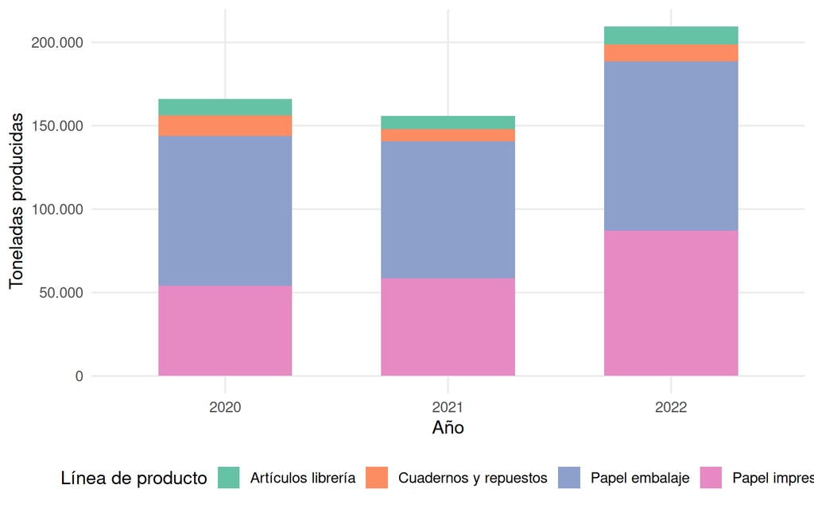

Figure 2: Composición anual de la producción total en toneladas (2020–2022). Fuente: Elaboración propia basada en Guimera Gauna (2022).

### Figura 3. Participación porcentual por línea de producto

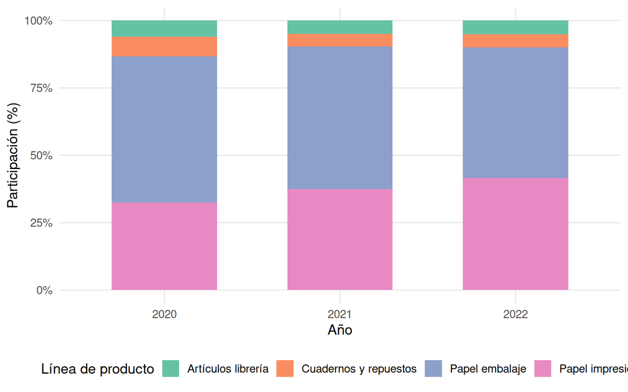

Figure 3: Participación porcentual de cada línea de producto en la producción total anual (2020–2022). Fuente: Elaboración propia basada en Guimera Gauna (2022).

## Conclusiones

El caso Ledesma ilustra cómo una empresa agroindustrial puede reconfigurar su modelo de negocio frente a shocks de demanda estructurales —como la digitalización— sin abandonar su núcleo de competencias. La integración vertical basada en bagazo de caña de azúcar no solo reduce costos de materia prima, sino que habilita una narrativa de sostenibilidad coherente y verificable, relevante tanto para consumidores finales como para compradores institucionales y reguladores (Bellomo, 2025).

La transición hacia packaging compostable y papel tissue premium posiciona a Ledesma en segmentos de mayor valor agregado, con menor exposición a la sustitución digital y mayor alineación con las tendencias de economía circular que dominan la agenda regulatoria global (Lacabana, 2019; Salatin, 2024).

## Referencias

Avellaneda, M. D. (2023). *Planificación estratégica para la unidad de celulosa y papel de la Empresa Ledesma en la unidad estratégica de negocios Papel* [Unpublished manuscript].

Bellomo, L. (2025). *Innovación sustentable mediante integración vertical: Desarrollo de packaging compostable para la línea de azúcar de Grupo Ledesma* [Unpublished manuscript].

Guimera Gauna, A. N. (2022). *Viabilidad de exportar resmas de hoja A4 de biopapel a Perú* [Unpublished manuscript].

Lacabana, M. (Ed.). (2019). *Economía y ambiente: El subsistema celulosa-papel en la Argentina*. Universidad Nacional de Quilmes.

Salatin, A. (2024). *Estrategia de diversificación relacionada para la unidad papelera de Ledesma: Línea Ledesma NAT Tissue* [Unpublished manuscript].